# Microbial Compositional Analysis Across Different Soils

Antone Jung

April 25, 2025

# Goals

In this file, we will perform compositional analysis of our scaled/noramlized/rarefied microbial dataset!

1. Load in scaled/normalized phyloseq object.
2. Calculate the relative abundances of taxonomic groups at various levels: A. Phylum B. Genus C. ASV
3. Plot them, and narrow in on specific taxnomic group of interest
1. We will need the `scaled_physeq.RData`, which includes a rooted tree that we created in `analysis/06_Ordination/scaled_physeq.RData`.

## Outputs

# Compositional Data

Microbial abundance data—like 16S rRNA gene or metagenomics data—are typically **compositional:** they represent relative abundances constrained to a constant total (*e.g.,* percent or proportions). This introduces spurious correlations and other issues if analyzed with traditional statistics. This is a very important limitation to microbial data!

INTERPRETATION #1: When a relative abundance increases, its ambiguous if the population grew or the surrounding community shrunk. Especially when looking at environmental variables, the distinction between something being beneficial and something being less harmful to a species is significant.

# Setup

## Load Packages

```r
# Load in the packages
pacman::p_load(tidyverse, devtools, DT, phyloseq, patchwork,
               install = FALSE)

# load colors
source("code/colors.R")
```

## 1. Load in Scaled Phyloseq object

```r
load("data/06_Ordination/scaled_physeq.RData")

# Look at the data
scaled_physeq
```

```
## phyloseq-class experiment-level object
## otu_table()   OTU Table:         [ 9286 taxa and 36 samples ]
## sample_data() Sample Data:       [ 36 samples by 9 sample variables ]
## tax_table()   Taxonomy Table:    [ 9286 taxa by 9 taxonomic ranks ]
## phy_tree()    Phylogenetic Tree: [ 9286 tips and 9285 internal nodes ]
```

```r
min(sample_sums(scaled_physeq))
```

```
## [1] 9539
```

```r
range(sample_sums(scaled_physeq))
```

```
## [1] 9539 9539
```

# Taxonomic Analysis!

In this analysis, we will drill down from phylum to ASV level analyses, which will enable increasingly detailed insights into microbial diversity and potential ecological roles. However, it is also important for us to remember that deeper levels also come with increased noise and data sparsity, especially for rare groups.

## A. Phylum

Taxonomic analysis often begins at broader levels (*e.g.,* Phylum) to visualize overarching trends before zooming in on finer-scale patterns. This step allows us to identify which microbial groups dominate across samples and which may respond to environmental gradients like salinity.

Now, let’s calculate the relative abundance of the phyla across all the samples. **NOTE:** To do this, it is imperative that we have scaled the data to a constant sequencing depth.

```r
# Create a phylum level dataframe
phylum_df <-
  scaled_physeq %>%
  # Agglomerate all ASV counts within a phylum
  tax_glom(taxrank = "Phylum") %>%
  # Calculate the relative abundance!
  transform_sample_counts(function(x) {x/sum(x)}) %>%
  # Create a dataframe from phyloseq object
  psmelt() %>%
  # Filter out Phyla < 1 %
  dplyr::filter(Abundance > 0.01) %>%
  mutate(soil_type = fct_relevel(soil_type, c("Sand", "Florence", "Pendelton", "Lansing")))

## What are the phylum abundances?
phylum_df %>%
  group_by(Phylum) %>%
  summarize(mean_PercAbund = round(mean(Abundance), digits = 4)) %>%
  arrange(-mean_PercAbund) %>%
  datatable()
```

|  | Phylum | mean_PercAbund |
| --- | --- | --- |
| 1 | Pseudomonadota | 0.3509 |
| 2 | Bacteroidota | 0.1083 |
| 3 | Myxococcota | 0.0877 |
| 4 | Actinomycetota | 0.0731 |
| 5 | Fibrobacterota | 0.0696 |
| 6 | Acidobacteriota | 0.0651 |
| 7 | Chloroflexota | 0.0642 |
| 8 | Bacillota | 0.0638 |
| 9 | Planctomycetota | 0.0565 |
| 10 | Thermoproteota | 0.0453 |

[output cut: 12 more lines]

```r
# Make a list of phyla the top phyla
top10_phyla <-
  phylum_df %>%
  group_by(Phylum) %>%
  summarize(mean_PercAbund = mean(Abundance)) %>%
  arrange(-mean_PercAbund) %>%
  head(n = 10) %>%
  pull(Phylum)
```

## Stacked Bar plots

Visualization helps detect patterns in composition and abundance that statistical models may later test. Stacked bar plots are often used but can obscure individual sample variation and visualize too much data all at once.

Therefore, we will also explore faceted and jittered boxplots below the bar plots to see sample-level trends more clearly.

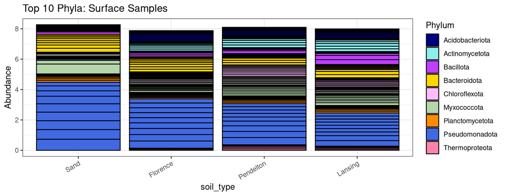

```r
# Stacked Bar Plot With All phyla
# Plot Phylum Abundances - make sure to load phylum_colors
phylum_df %>%
  dplyr::filter(Phylum %in% top10_phyla) %>%
  # Warning: It's important to have one sample per x value,
  # otherwise, it will take the sum between multiple samples
  ggplot(aes(x = soil_type, y = Abundance, fill = Phylum)) +
  geom_bar(stat = "identity", color = "black") +
  labs(title = "Top 10 Phyla: Surface Samples") +
  scale_fill_manual(values = phylum_colors) +
  theme_bw() +
  theme(axis.text.x = element_text(angle = 30, hjust = 1, vjust = 1))
```

## Faceted Bar plot

To help compare the phylum abundance between sample types, we can facet by phylum to better see how the changes occur across the stations, which is masked in the stacked bar plot. It’s a little better than the stacked bar plot, however, we can do even better!

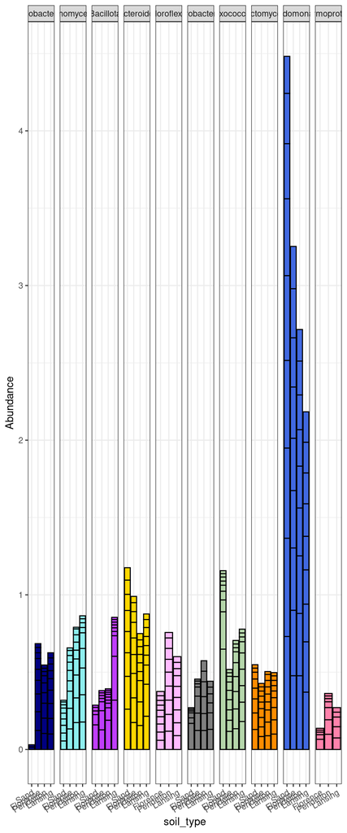

```r
phylum_df %>%
  dplyr::filter(Phylum %in% top10_phyla) %>%
  # Individual sample comparison of surface waters, whole fraction
  # This will allow us to look at individual samples!
  # Note that whenever plotting stacked bar plots, you should always look at Individual samples!
  ggplot(aes(x = soil_type, y = Abundance, fill = Phylum)) +
  facet_grid(~Phylum, scale = "free") +
  # add the stacked bar
  geom_bar(stat = "identity", color = "black") +
  # change the colors to be our selected colors
  scale_fill_manual(values = phylum_colors) +
  theme_bw() +
  theme(legend.position = "none",
        axis.text.x = element_text(angle = 30, hjust = 1, vjust = 1))
```

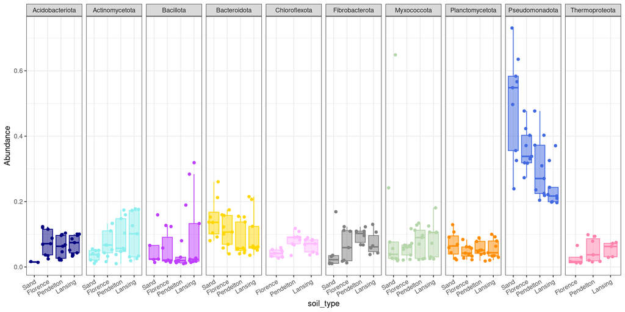

```r
### Or combined together:
phylum_df %>%
  dplyr::filter(Phylum %in% top10_phyla) %>%
  ggplot(aes(x = soil_type, y = Abundance, fill = Phylum, color = Phylum)) +
  facet_grid(~Phylum, scale = "free") +
  # add the stacked bar
  geom_jitter() +
  geom_boxplot(outlier.shape = NA, alpha = 0.5) +
  # change the colors to be our selected colors
  scale_fill_manual(values = phylum_colors) +
  scale_color_manual(values = phylum_colors) +
  theme_bw() +
  theme(legend.position = "none",
        axis.text.x = element_text(angle = 30, hjust = 1, vjust = 1))
```

Microbial community composition varied markedly across the soil types! Specifically, several phyla display clear spatial structuring, which is exciting. Of particular interest are myxococcota, pseudomonadota, thermoproteota, and actinomycetota.

Some specific results:

- **Acidobacteria** hovered around the same value for all ERH soils, while sand (not innoculated with ERH) had lower counts (although this may be due to small sample size)
- **Pseudomonadota** (formerly Proteobacteria, especially Gammaproteobacteria) had high abundance across all soil types, but increased as soil carbon decreased, so it is possibly outcompeted by organisms that thrive in more nutrient rich environments. **Bacteroidota** also reflected this inverse relationship, but to a lesser extent since it is not as prevalent.
- **Bacillota** and **Planctomycetota** remain relatively constant across all soil types. They are well adapted to all conditions.
- **Actinomycetota**, **Myxococcota**, and **Thermoproteota** displayed a direct relationship between soil carbon and relative abundance. Since myxococcota characteristically is predatory, as more resources are available for its prey, it also thrives.
- **Chloroflexota** and **Fibrobacteria** have an interesting arch where Pendelton soils with intermediate levels of carbon are most beneficiial for this genera.

After initial exploration, we focus on specific phyla that appear to vary across soil_types. These targeted plots help develop hypotheses about ecological drivers.

- Myxococcota
- Thermoproteota
- Actinomycetota
- Pseudomonadota

### A1. Myxococcota

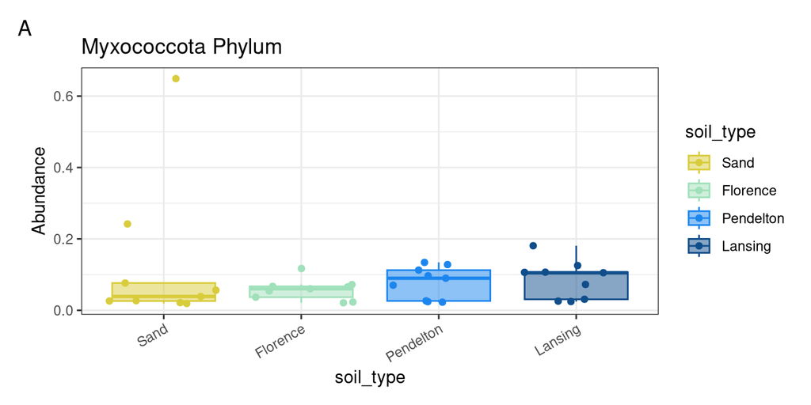

```r
# Narrow in on a specific group
# Myxo - y: abundance, x: station, dot plot + boxplot
myxo_phylum_soil <-
  phylum_df %>%
  dplyr::filter(Phylum == "Myxococcota") %>%
  # build the plot
  ggplot(aes(x = soil_type, y = Abundance,
             fill = soil_type, color = soil_type)) +
  geom_boxplot(alpha = 0.5, outlier.shape = NA) + # outliers not plotted here in boxplot
  geom_jitter() +
  theme_bw() +
  labs(title = "Myxococcota Phylum") +
  scale_color_manual(values = soil_colors) +
  scale_fill_manual(values = soil_colors) +
    theme(axis.text.x = element_text(angle = 30, hjust = 1, vjust = 1),
          legend.position = "right")
# Statistically: Kruskall-Wallis followed by a Tukey's Posthoc test
# These are non-parametric (non-normal) stat tests



# Collect both of the plots together into one
myxo_phylum_soil +
  plot_layout(guides = "collect") +
  plot_annotation(tag_levels = "A")
```

### A2. Thermoproteota

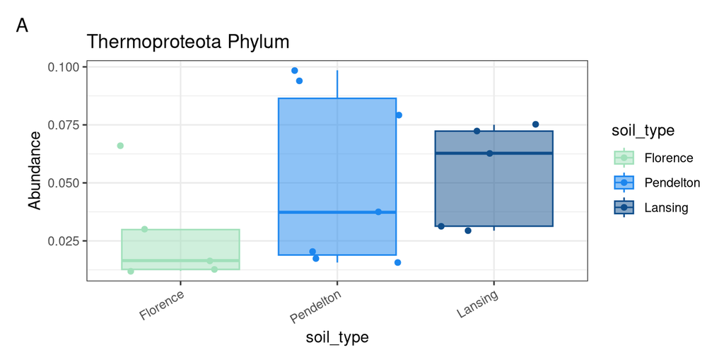

```r
# Narrow in on a specific group
# Cyanobacteriota - y: abundance, x: station, dot plot + boxplot
thermo_phylum_soil <-
  phylum_df %>%
  dplyr::filter(Phylum == "Thermoproteota") %>%
  # build the plot
  ggplot(aes(x = soil_type, y = Abundance,
             fill = soil_type, color = soil_type)) +
  geom_boxplot(alpha = 0.5, outlier.shape = NA) + # outliers not plotted here in boxplot
  geom_jitter() +
  theme_bw() +
  labs(title = "Thermoproteota Phylum") +
  scale_color_manual(values = soil_colors) +
  scale_fill_manual(values = soil_colors) +
    theme(axis.text.x = element_text(angle = 30, hjust = 1, vjust = 1),
          legend.position = "right")
# Statistically: Kruskall-Wallis followed by a Tukey's Posthoc test
# These are non-parametric (non-normal) stat tests



# Collect both of the plots together into one
thermo_phylum_soil +
  plot_layout(guides = "collect") +
  plot_annotation(tag_levels = "A")
```

### A3. Actinomycetota

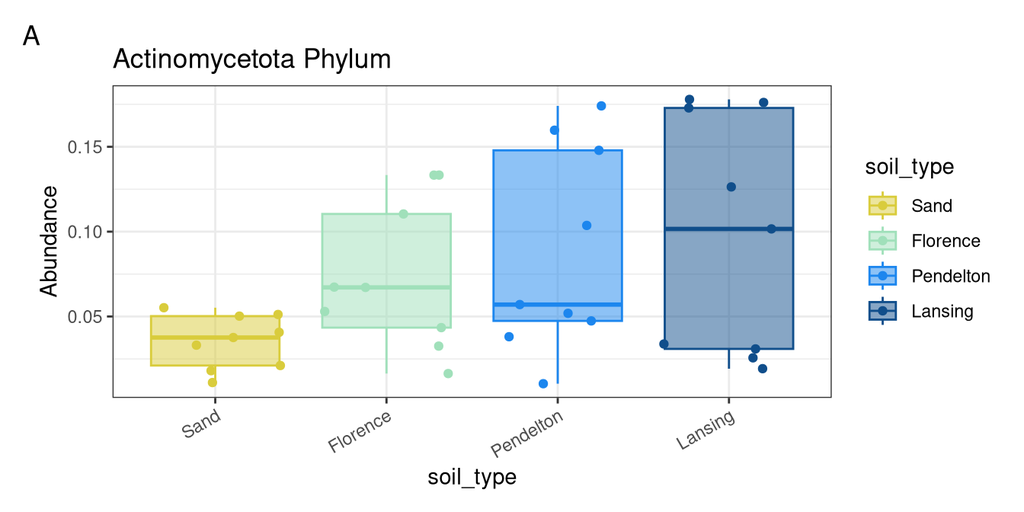

```r
actino_phylum_soil <-
  phylum_df %>%
  dplyr::filter(Phylum == "Actinomycetota") %>%
  # build the plot
  ggplot(aes(x = soil_type, y = Abundance,
             fill = soil_type, color = soil_type)) +
  geom_boxplot(alpha = 0.5, outlier.shape = NA) + # outliers not plotted here in boxplot
  geom_jitter() +
  theme_bw() +
  labs(title = "Actinomycetota Phylum") +
  scale_color_manual(values = soil_colors) +
  scale_fill_manual(values = soil_colors) +
    theme(axis.text.x = element_text(angle = 30, hjust = 1, vjust = 1),
          legend.position = "right")
# Statistically: Kruskall-Wallis followed by a Tukey's Posthoc test
# These are non-parametric (non-normal) stat tests



# Collect both of the plots together into one
actino_phylum_soil +
  plot_layout(guides = "collect") +
  plot_annotation(tag_levels = "A")
```

### A4. Pseudomondota

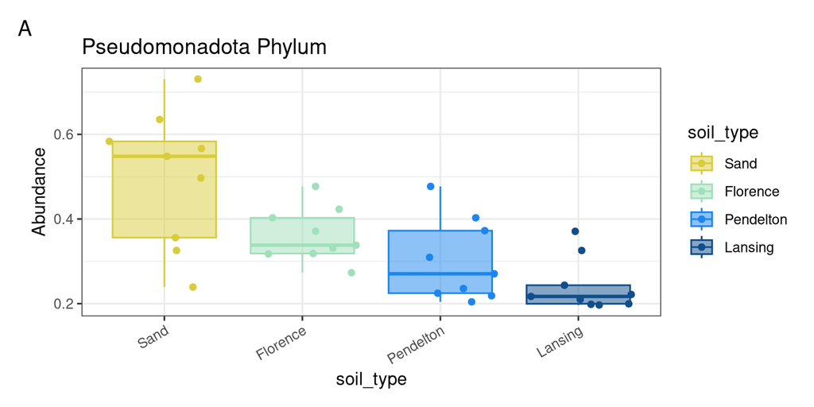

```r
pseudo_phylum_soil <-
  phylum_df %>%
  dplyr::filter(Phylum == "Pseudomonadota") %>%
  # build the plot
  ggplot(aes(x = soil_type, y = Abundance,
             fill = soil_type, color = soil_type)) +
  geom_boxplot(alpha = 0.5, outlier.shape = NA) + # outliers not plotted here in boxplot
  geom_jitter() +
  theme_bw() +
  labs(title = "Pseudomonadota Phylum") +
  scale_color_manual(values = soil_colors) +
  scale_fill_manual(values = soil_colors) +
    theme(axis.text.x = element_text(angle = 30, hjust = 1, vjust = 1),
          legend.position = "right")
# Statistically: Kruskall-Wallis followed by a Tukey's Posthoc test
# These are non-parametric (non-normal) stat tests



# Collect both of the plots together into one
pseudo_phylum_soil +
  plot_layout(guides = "collect") +
  plot_annotation(tag_levels = "A")
```

INTERPRETATION #4: Thermoproteota and Myxococcota both show positive relationships between nutrient level and abundance. Pseudomonadota has a stark decline as nutrient levels increase, but this may be a result as it is outcompeted by other phyla. It’s characteristically an allelopathic organism, so at low nutrient levels, it may be able to suppress the growth of surrounding phyla.

## B. Genus

Let’s first calculate the genus data frame.

```r
# Calculate the Family relative abundance
# Note: The read depth MUST be normalized in some way: scale_reads
genus_df <-
  scaled_physeq %>%
  # agglomerate at the phylum level
  tax_glom(taxrank = "Genus") %>%
  # Transform counts to relative abundance
  transform_sample_counts(function (x) {x/sum(x)}) %>%
  # Melt to a long format
  psmelt() %>%
  # Fix the order of date
  mutate(
         soil_type = fct_relevel(soil_type, c("Sand", "Florence", "Pendelton", "Lansing")))
```

### B1. Thermoproteota Genera

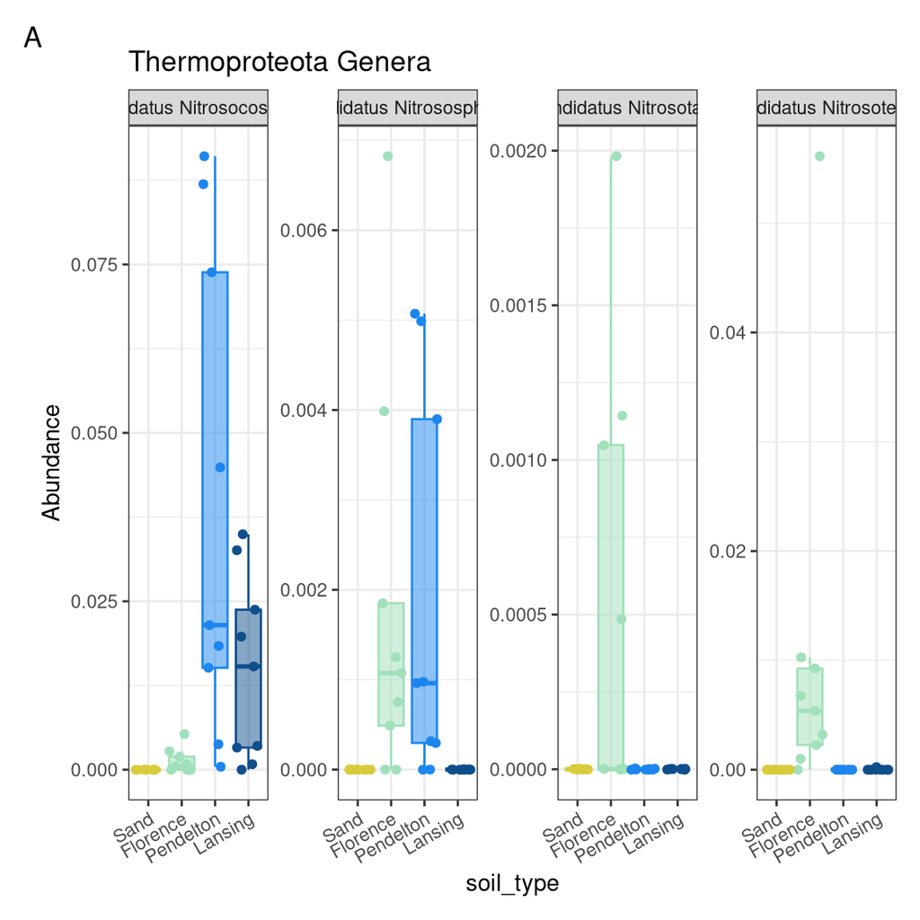

```r
# Plot genus
thermo_genus_soil <-
  genus_df %>%
  dplyr::filter(Phylum == "Thermoproteota") %>%
  # At first, plot all of the genera and then subset the ones that have intersting trends
  # dplyr::filter(Genus %in% c("hgcI clade", "CL500-29 marine group")) %>%
  # build the plot
  ggplot(aes(x = soil_type, y = Abundance,
             fill = soil_type, color = soil_type)) +
  facet_wrap(.~Genus, scales = "free_y", nrow = 1) +
  geom_boxplot(alpha = 0.5, outlier.shape = NA) + # outliers not plotted here in boxplot
  geom_jitter() +
  theme_bw() +
  labs(title = "Thermoproteota Genera") +
  scale_color_manual(values = soil_colors) +
  scale_fill_manual(values = soil_colors) +
  theme(axis.text.x = element_text(angle = 30, hjust = 1, vjust = 1),
        legend.position = "none")

thermo_genus_soil +
  plot_layout(guides = "collect") +
  plot_annotation(tag_levels = "A")
```

### B2. Myxo Genera

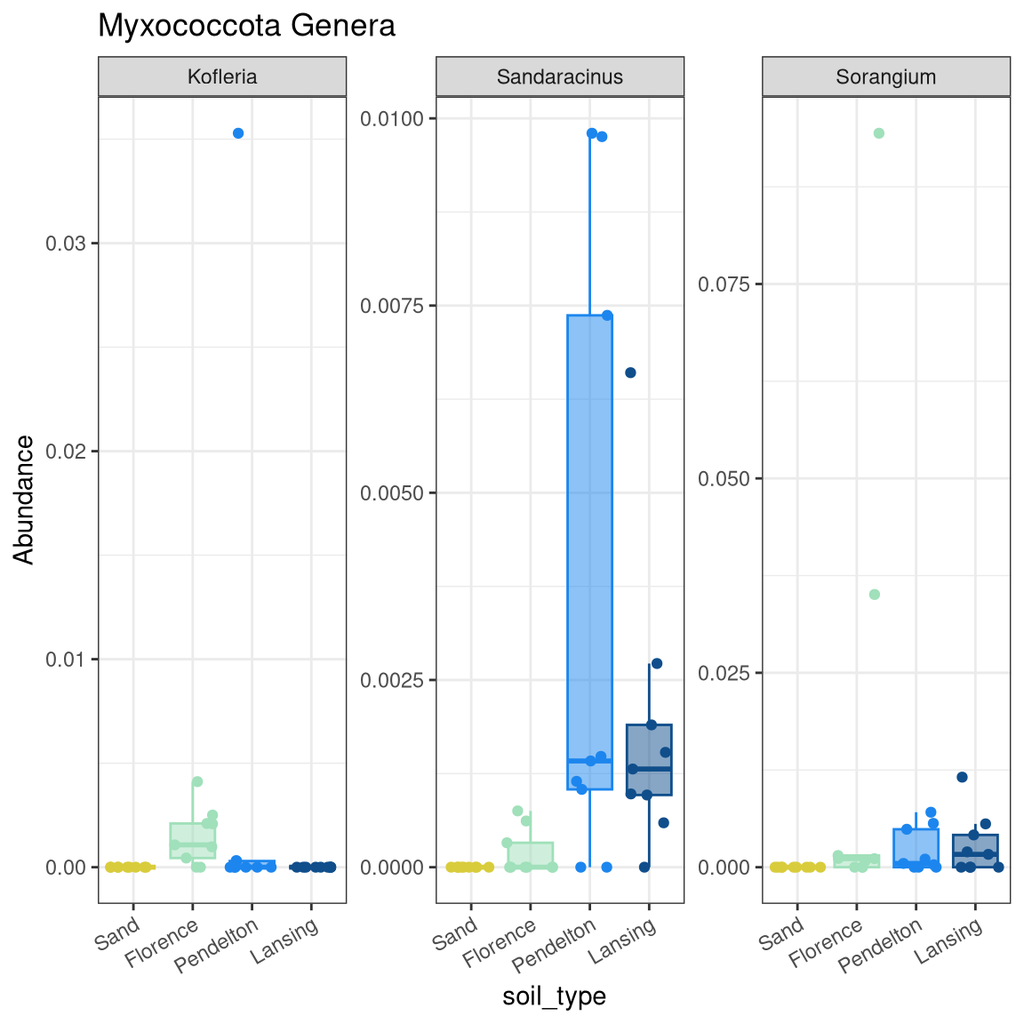

```r
myxo_genus_soil <-
  genus_df %>%
  dplyr::filter(Phylum == "Myxococcota") %>%
  # At first, plot all of the genera and then subset the ones that have intersting trends
  dplyr::filter(Genus %in% c("Sandaracinus", "Sorangium", "Kofleria")) %>%
  # build the plot
  ggplot(aes(x = soil_type, y = Abundance,
             fill = soil_type, color = soil_type)) +
  facet_wrap(.~Genus, scales = "free_y", nrow = 1) +
  geom_boxplot(alpha = 0.5, outlier.shape = NA) + # outliers not plotted here in boxplot
  geom_jitter() +
  theme_bw() +
  labs(title = "Myxococcota Genera") +
  scale_color_manual(values = soil_colors) +
  scale_fill_manual(values = soil_colors) +
  theme(axis.text.x = element_text(angle = 30, hjust = 1, vjust = 1),
        legend.position = "none")
myxo_genus <- genus_df %>% dplyr::filter(Phylum == "Myxococcota")
myxo_genus_soil
```

INTERPRETATION #5: There is a huge variability across genera. Even with Thermoproteota, which seemed to have a strong correlation between nutrient level and abundance, individual genera tell a different story.

## C. ASV level

```r
# Calculate the Family relative abundance
# Note: The read depth MUST be normalized in some way: scale_reads
ASV_df <-
  scaled_physeq %>%
  # Prune out ASVs that have fewer than 100 counts!
  ## LOOK AT HOW MANY ARE REMOVED! We scaled to 9539 reads!
  prune_taxa(taxa_sums(.) >= 954, .) %>%
  # agglomerate at the phylum level
  tax_glom(taxrank = "ASV") %>%
  # Transform counts to relative abundance
  transform_sample_counts(function (x) {x/sum(x)}) %>%
  # Melt to a long format
  psmelt() %>%
  # fix the order of date
mutate(
         soil_type = fct_relevel(soil_type, c("Sand", "Florence", "Pendelton", "Lansing")))
```

### C1. Myxo ASVs

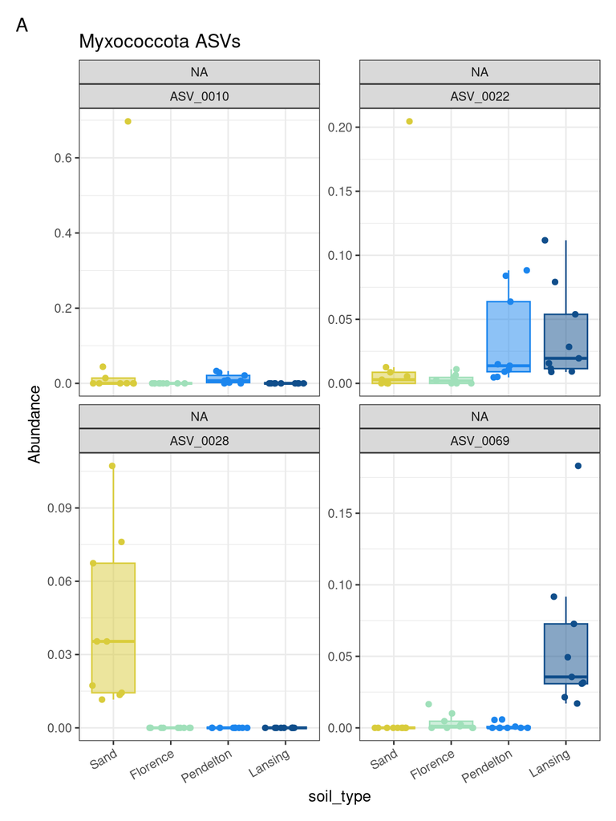

```r
top_myxo_ASVs <-
  ASV_df %>%
  dplyr::filter(Phylum == "Myxococcota") %>%
  group_by(ASV) %>%
  summarize(mean_Abundance = mean(Abundance)) %>%
  dplyr::filter(mean_Abundance > 0.005) %>%
  pull(ASV)

myxo_asv_soil <-
  ASV_df %>%
  dplyr::filter(ASV %in% top_myxo_ASVs) %>%
  # build the plot
  ggplot(aes(x = soil_type, y = Abundance,
             fill = soil_type, color = soil_type)) +
  facet_wrap(Genus~ASV, scales = "free_y", nrow = 2) +
  geom_boxplot(alpha = 0.5, outlier.shape = NA) + # outliers not plotted here in boxplot
  geom_jitter() +
  theme_bw() +
  labs(title = "Myxococcota ASVs") +
  scale_color_manual(values = soil_colors) +
  scale_fill_manual(values = soil_colors) +
  theme(axis.text.x = element_text(angle = 30, hjust = 1, vjust = 1),
        legend.position = "none")

myxo_asv_soil +
  plot_layout(guides = "collect") +
  plot_annotation(tag_levels = "A")
```

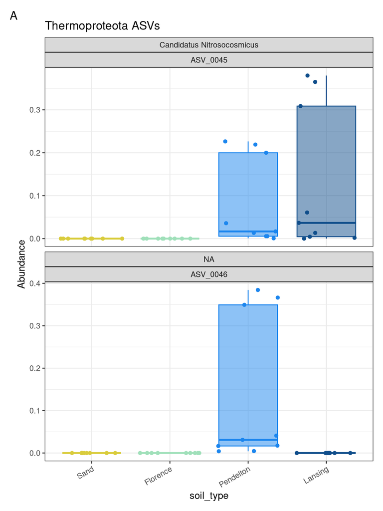

```r
top_thermo_ASVs <-
  ASV_df %>%
  dplyr::filter(Phylum == "Thermoproteota") %>%
  group_by(ASV) %>%
  summarize(mean_Abundance = mean(Abundance)) %>%
  dplyr::filter(mean_Abundance > 0.005) %>%
  pull(ASV)

thermo_asv_soil <-
  ASV_df %>%
  dplyr::filter(ASV %in% top_thermo_ASVs) %>%
  # build the plot
  ggplot(aes(x = soil_type, y = Abundance,
             fill = soil_type, color = soil_type)) +
  facet_wrap(Genus~ASV, scales = "free_y", nrow = 2) +
  geom_boxplot(alpha = 0.5, outlier.shape = NA) + # outliers not plotted here in boxplot
  geom_jitter() +
  theme_bw() +
  labs(title = "Thermoproteota ASVs") +
  scale_color_manual(values = soil_colors) +
  scale_fill_manual(values = soil_colors) +
  theme(axis.text.x = element_text(angle = 30, hjust = 1, vjust = 1),
        legend.position = "none")

thermo_asv_soil +
  plot_layout(guides = "collect") +
  plot_annotation(tag_levels = "A")
```

INTERPRETATION #6: ASV_0010, ASV_0022, ASV_0028, and ASV_0069 for myxococcota. For Thermoproteota, Candidatus Nitrosocoscmicus (ASV_0045) and ASV_0046 were the most abundant.

INTERPRETATION #8: The ASVs for Myxo are NA, while in Thermoproteota, one of the ASVs of interest is Candidatus Nitrosocoscmicus. This is interesting since it’s a ammonia oxidizing bacteria, which plays a role in the nitrogen cyclign of an environment.